# Quality Assurance - Ethics

# 1 Learning Objectives

After this module you will:

- Be aware of the requirements of general purpose data ethics and how they are related to predictive modelling
- Understand how model systems can be opaque
- Understand why design decisions need to be recorded
- Be aware of how prediction systems can reinforce bias
- Understand the requirements of contestability
- Understand why conviction measures are useful for ethical applications
- Understand why outcome analysis for protected and non-protected characteristics prevents unethical applications

# 2 Ethical Applications of Predictive Modelling

An increasing trend across industries, public and private, is to automate decision making, often using predictive modelling systems to achieve this.

While there are benefits to doing this, this trend increases the possible harm to society if the models used are: not quality assured or not ethical applications of predictive modelling. Cost is often a factor in automated decision making.

It is common to view predictive modelling as a technical challenge. It is not. It is a challenge with technical components, organisational elements and ethical considerations.

**No predictive modelling system exists in isolation.** It is both influenced and influences society. It needs to comply with legal and ethical frameworks.

Predictive models do not predict the future out of nowhere, they encode the past and recreate patterns. Structural inequalities, biases and attitudes in society are put into our models in the form of data, and design choices.

Due to the scalability of data products, the risks associated with predictive modelling on individuals lives is substantial. When Facebook changes it’s algorithm on what news people see (potentially harmful news), it impacts it’s 2.8 billion monthly users immediately. If the Department for Work and Pensions changes how it detects Universal Credit fraud, it will impact 6 million people (as of January 2021), with potential legal, life altering sanctions.

The challenge of creating ethical models therefore necessitates a wide, multidisciplinary approach using both analytical techniques and questions of morality and equity. An analyst should never be left alone to make determinations of ethical questions in their models.

This module is not a fully comprehensive exploration of ethics in predictive modelling, there are substantial open questions in the field with enough content to cover many courses. Instead, this course highlights key elements of predictive modelling systems where ethics has an important role to play. We will be able to ask relevant questions for quality assurance from an ethical perspective as a result.

To supplement this module, it is recommended participants engage with a wide range of reading materials, such as [Data Feminism by Catherine D’Ignazio and Lauren F. Klein](https://data-feminism.mitpress.mit.edu/).

**There is guidance on [“Ethics, Transparency and Accountability Framework for Automated Decision-Making”](https://www.gov.uk/government/publications/ethics-transparency-and-accountability-framework-for-automated-decision-making/ethics-transparency-and-accountability-framework-for-automated-decision-making) provided from the Office for Aritificial Intelligence and Central Digital & Data Office.** There is in addition a [risk assessment form](https://www.gov.uk/government/publications/ethics-transparency-and-accountability-framework-for-automated-decision-making?utm_source=Data&utm_medium=Slack&utm_campaign=automation) to complete when using algorithmic decision making in the public sector. These documents are extremely useful to support the process of designing an automated decision making system.

# 3 General Data Ethics

Predictive modelling introduces extra, interesting ethical questions on the use of data. However, **it does not overrule other existing conventions and standards for the ethical use of data**. These same standards for data storage, collection, sharing, and analysis need to be complied with regardless of how the data is being applied.

In this section we will explore what these general data ethical considerations. While ethical considerations are not identical to legal requirements we will look at both the UK Statistical Authority’s Ethical Principles and UK General Data Protection Regulation.

It is important to note that throughout this ethical exploration the burden is always going to be on the entity **using** the data, in our case the analyst / data manager, they will need to justify why what they are doing is correct. This course is not legal guidance, please refer to the ICO and your own data protection teams for this.

If we follow all of the GDPR guidelines we will be a step toward having an ethical predictive model.

The term **personal data** is important here, it refers to data about a living person:

- that can be identified or who are identifiable, directly from the information in question; or
- who can be indirectly identified from that information in combination with other information.

Truly anonymous data is not covered by GDPR. Partially anonymous data, that can be used to piece together an identity is covered. Data about corporations or public authorities is not covered.

## 3.1 UK Statistics Authority Ethical Principles

These ethical principles should be your first port of call. They lay out the important high level considerations when working with data.

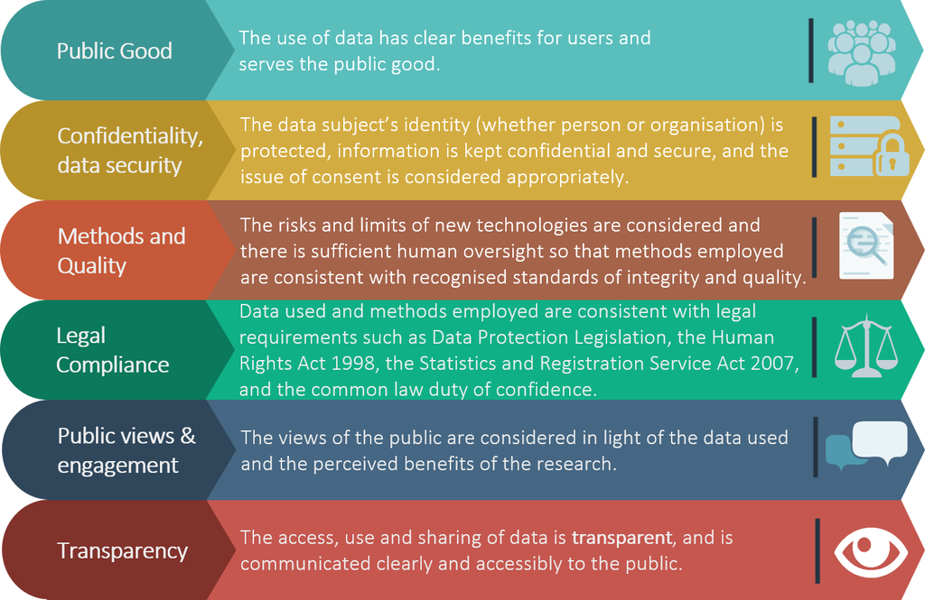

Figure 3.1: The UKSA Ethical Principles. [Image obtained from the UKSA website](https://uksa.statisticsauthority.gov.uk/about-the-authority/committees/national-statisticians-data-ethics-advisory-committee/ethical-principles/).

**Principles**

1. The use of data has clear benefits for users and serves the public good.
2. The data subject’s identity (whether person or organisation) is protected, information is kept confidential and secure, and the issue of consent is considered appropriately.
3. The risks and limits of new technologies are considered and there is sufficient human oversight so that methods employed are consistent with recognised standards of integrity and quality.
4. Data used and methods employed are consistent with legal requirements such as Data Protection Legislation, the Human Rights Act 1998, the Statistics and Registration Service Act 2007 and the common law duty of confidence.
5. The views of the public are considered in light of the data used and the perceived benefits of the research.
6. The access, use and sharing of data is transparent, and is communicated clearly and accessibly to the public.

**An ethics assessment should be completed for projects, an [example tool is provided by UKSA.](https://uksa.statisticsauthority.gov.uk/about-the-authority/committees/national-statisticians-data-ethics-advisory-committee/ethics-self-assessment-tool/)**

## 3.2 Principles of UK GDPR

We will first address principle 4, which relates to legal requirements.

The key components and what they may mean for us are given below. For a more comprehensive explanation [see the ICO website](https://ico.org.uk/for-organisations/guide-to-data-protection/guide-to-the-general-data-protection-regulation-gdpr/principles/)

### 3.2.1 Lawfulness, fairness and transparency

- **Individuals must know how their data is going to be used**
- Data must be obtained lawfully
- The use of the data must be fair to the individual concerned

Our users must know that we will be using their data to build a model. The use of the data must not be unexpected to the individual and they must know that it is being collected.

**Quality Questions**

Was this data obtained lawfully?

### 3.2.2 Purpose limitation

- The purpose of data collection must be clearly communicated to the individual
- The purpose of data collection must be recorded
- **The data can only be used for another purpose if 1) it is compatible with the original purpose, 2) consent is given, 3) it is a legal requirement to do so**

If we have data for an individual for another purpose (such as analysis/reporting), we need to either get consent or have appropriate grounds to use it for model building.

**Quality Questions**

Does the individual know what the purpose of the collection is?

### 3.2.3 Data minimisation

The data processing needs to be:

- Adequate - enough to meet the purpose stated
- Relevant - related to the purpose clearly
- Limited - no more than necessary for the purpose

We shouldn’t create a model just because we have data to do so. We should only use data for the purpose that the user agreed to. If the data is no longer being used to the purpose stated, we should not be collecting it, and dispose of it.

**Quality Questions**

Is the data we have relevant to the allowed purpose?

### 3.2.4 Accuracy

- Steps must be taken to avoid data held being inaccurate or misleading
- Personal data may need to be updated

For our modelling purpose we want as accurate data as possible, so it should be in our interests to ensure this.

**Quality Questions**

Is the data being used accurate?

### 3.2.5 Storage limitation

- You must not keep personal data for longer than you need it
- **You need to think about – and be able to justify – how long you keep personal data. This will depend on your purposes for holding the data.**
- You can keep personal data for longer if you are only keeping it for public interest archiving, scientific or historical research, or statistical purposes.

Models are built upon the data they are trained with. It is crucial this data is available for quality assuring and reproducing the model. If we are not able to retain the data then we should not use a model with it long term.

If a model is a synthesis of personal data, it can be personal data itself. Therefore if the data used to train it needs to be removed after a period, so will the model. As we have mentioned throughout this course, a model is data (in the case of some models, quite literally the model is saved as the raw data) and therefore needs to be GDPR compliant.

**Quality Questions**

How long are you able to keep the training data for the model?

### 3.2.6 Integrity and confidentiality (security)

The personal data held must be securely stored.

There are a range of ways that data can be stored, ranging from a written document* to a database of transactions stored in the cloud, or even a spreadsheet on your work laptop.

The appropriate level of secure storage for the type of data involved must be used. A data protection officer should be able to support in this.

Consider, who has access to this data? How is the data accessed? Is the data stored in an encrypted manner? Are special permissions, training or technologies required?

Unlikely to be used in a machine learning model… unless you are trying to [classify hand-writen documents](https://en.wikipedia.org/wiki/Optical_character_recognition).

**Quality Questions**

How is the data stored?

### 3.2.7 Accountability

Any decisions made about the processing and collection of personal data must be recorded. This helps to ensure that responsibility for that data is kept. This may be the role of the data manager, or another person depending on the organisation structure. It is important that a record of what processing takes place exists.

**Quality Questions**

Have decisions relating to the processing of the data been recorded?

## 3.3 Automated Decision Making

There are a [range of rights given to individuals under GDPR](https://ico.org.uk/for-organisations/guide-to-data-protection/guide-to-the-general-data-protection-regulation-gdpr/individual-rights/).

**They all need to be complied with**. However, the one of particular relevance to predictive modelling is **rights in relation to automated decision making and profiling**.

Even if we are not using predictive modelling for an automated individual decision-making process, we should still follow the good practice and standards set out here.

Throughout the rest of this module we will focus on how to ensure these rights are being protected.

For a short overview this [blog discusses at a high level approaches to AI with data protection.](https://techgdpr.com/blog/develop-artificial-intelligence-ai-gdpr-friendly/)

To avoid miscommunicating the requirements of this section, the checklists given by the ICO is given below, click the title to view each of the two checklists.

**Quality Questions**

Have all parts of the checklist been met with regards to automated individual decision making rights?

For further reading on the subject, see the ICO’s own paper on [“Big data, artificial intelligence, machine learning and data protection”](https://ico.org.uk/media/for-organisations/documents/2013559/big-data-ai-ml-and-data-protection.pdf).

There are two types of automated individual decision making and profiling (AIDMP) systems.

### All AIDMP

**To comply with the UK GDPR**

- We have a lawful basis to carry out profiling and/or automated decision-making and document this in our data protection policy.
- We send individuals a link to our privacy statement when we have obtained their personal data indirectly.
- We explain how people can access details of the information we used to create their profile.
- We tell people who provide us with their personal data, how they can object to profiling, including profiling for marketing purposes.
- We have procedures for customers to access the personal data input into the profiles so they can review and edit for any accuracy issues.
- We have additional checks in place for our profiling/automated decision-making systems to protect any vulnerable groups (including children).
- We only collect the minimum amount of data needed and have a clear retention policy for the profiles we create.

**As a model of best practice**

- We carry out a Data Protection Impact Assessment (DPIA) to consider and address the risks before we start any new automated decision-making or profiling.
- We tell our customers about the profiling and automated decision-making we carry out, what information we use to create the profiles and where we get this information from.
- We use anonymised data in our profiling activities.

### Solely AIDMP

**To comply with the UK GDPR**

- We carry out a DPIA to identify the risks to individuals, show how we are going to deal with them and what measures we have in place to meet UK GDPR requirements.
- We carry out processing under Article 22(1) for contractual purposes and we can demonstrate why it’s necessary.

OR

- We carry out processing under Article 22(1) because we have the individual’s explicit consent recorded. We can show when and how we obtained consent. We tell individuals how they can withdraw consent and have a simple way for them to do this.

OR

- We carry out processing under Article 22(1) because we are authorised or required to do so. This is the most appropriate way to achieve our aims.
- We don’t use special category data in our automated decision-making systems unless we have a lawful basis to do so, and we can demonstrate what that basis is. We delete any special category data accidentally created.
- We explain that we use automated decision-making processes, including profiling. We explain what information we use, why we use it and what the effects might be.
- We have a simple way for people to ask us to reconsider an automated decision.
- We have identified staff in our organisation who are authorised to carry out reviews and change decisions.
- We regularly check our systems for accuracy and bias and feed any changes back into the design process.

*As a model of best practice*

- We use visuals to explain what information we collect/use and why this is relevant to the process.
- We have signed up to [standard] a set of ethical principles to build trust with our customers. This is available on our website and on paper.

# 4 Opaque Model Systems

A common thread throughout this course will be that we do not want opaque predictive models. We will give more detail on methods for interpretable predictive models in later chapters, but here we will introduce some of the concepts that can make our models opaque, and why this has ethical implications.

Let’s remind ourselves of some key terms:

What makes up a predictive model?

- The learning algorithm chosen
- The data used to train the algorithm

And ultimately, those two things will be what they are due to **decisions made** by the designers. We will discuss more about these decisions shortly, but for now we will look at the models themselves, not how we got there.

## 4.1 Opaque Learning Algorithms

You may have noticed that there is not an explicit requirement to explain **how** a decision was come to within the rights relating to automated individual decision making. Instead there is more of a focus on what the information used, what the effect is and the purpose of the automated individual decision-making.

Although we are not legally required to explain **how**, being able to do so makes the other requirements set out **significantly easier**.

Under principle 3 of the Ethical Principles from UKSA; “The risks and limits of new technologies are considered and there is sufficient human oversight so that methods employed are consistent with recognised standards of integrity and quality.”

If a model system is opaque, and a human cannot understand how it works, then there **cannot** be adequate oversight. The quality of the model cannot be easily assured.

**It is much easier to measure bias and accuracy of our models if we can easily explain how they work**.

In order to fully understand how a decision was made, the properties of a learning algorithm that produced the predictive model must be understood. This does not mean the exact model needs to be understood, but how the learning algorithm works is a crucial first step. We do not want to use tools that we cannot explain.

If we cannot explain how an learning algorithm works how can we explain the results it produces?

Different learning algorithms, or model types, have very different structures and therefore need to be understood differently. Some lend themselves to interpretability more than others.

A learning algorithm such as ordinary least-squares can be easily understood, this means the resulting model will be easier to interpret directly.

For other learning algorithms such as ensemble methods we can understand how the algorithm works reasonably easily, but the resulting model is still highly complex.

A complex learning algorithm, such as a backpropagation in a neural network is more complex, which will make the resulting model hard to understand.

There are broadly two approaches to trying to understand why a model made a decision. How easily we can do this tells us how opaque the model is.

- Model-intrinsic methods - the learning algorithm and resulting model have properties which we can understand and infer why a decision was made. These properties will be different for each type of learning algorithm, such as coefficients, rules or probabilities. We can understand **completely** why a prediction was made.
- Model-agnostic methods - these can be used for any learning algorithm / model type. They do not look at properties of the model itself, but try to understand the predictions made through another framework. Each model agnostic approach gives as a **partial** picture as to why a prediction was made.

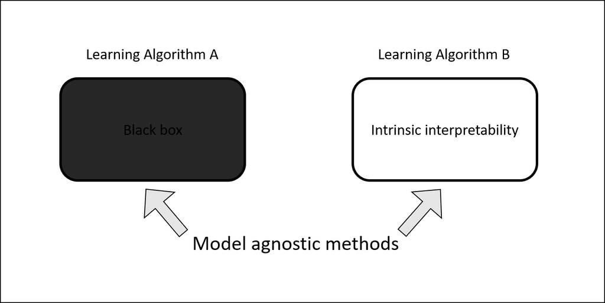

Figure 3.2: When a model is intrinsically interpretable we have a wider range of ways to investigate how it works. We can use model agnostic analysis on both opaque and non-opaque learning algorithms.

We then have a way to split different learning algorithms / model types. Those that can have model intrinsic interpretation, and those that cannot. For those that cannot our only option are model agnostic approaches.

A non-exhaustive list of learning algorithms with intrinsic interpretability:

- Generalised Linear Models, Generalised Additive Models
  - Including linear regression and logistic regression
- Decision Trees
  - If we group (ensemble) decision trees they may be harder to interpret, such as random forests or boosting approaches
- Decision Rules
  - Similar to decision trees, built on an IF-THEN structure learned from data
- RuleFit
  - A combination of decision rules and linear models, allowing for feature interaction
- Linear Support Vector Machines
  - Non-linear SVMs are harder to interpret intrinsically
- Naive Bayes
- K-Nearest Neighbour

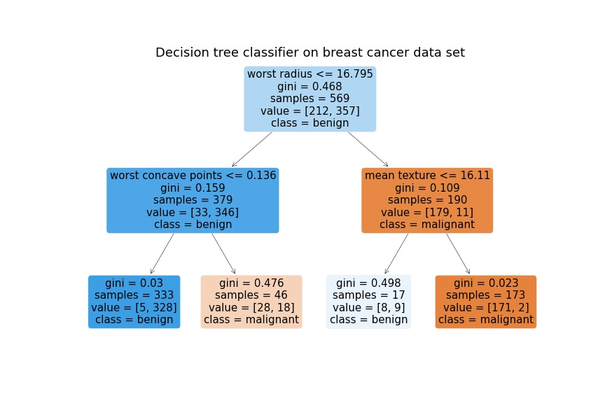

Figure 3.3: Example decision tree rules found on a classification task. Each step in the decision processes for an individual data point can be understood in terms of the original features given.

**Quality Questions**

Is this model intrinsically interpretable?

If not, what model agnostic approaches have been used to interpret it?

### 4.1.1 Opaqueness due to Randomness

* Not strictly opaqueness, but a factor which can make the interpretation of a model unclear.

There is an important point to make about how randomness can impact learning algorithms significantly, this should be taken into account when considering the opaqueness of a modelling process.

Many algorithms, including some used for highly interpretable models have a “backend” or “solver” that to varying degrees relies on stochastic processes.

This should be noted wherever possible.

The solution that a learning algorithm found may not be unique, or deterministic. Running the training again may produce a slightly different model, which can impact the decisions made by a model.

A “random state” is set by computer programs which defines how random numbers are generated within the machine. By choosing a different “random state” a different sequence of random numbers will be generated by the computer. This can lead to different starting points for some algorithms, and therefore if we are not careful, different predictions being made.

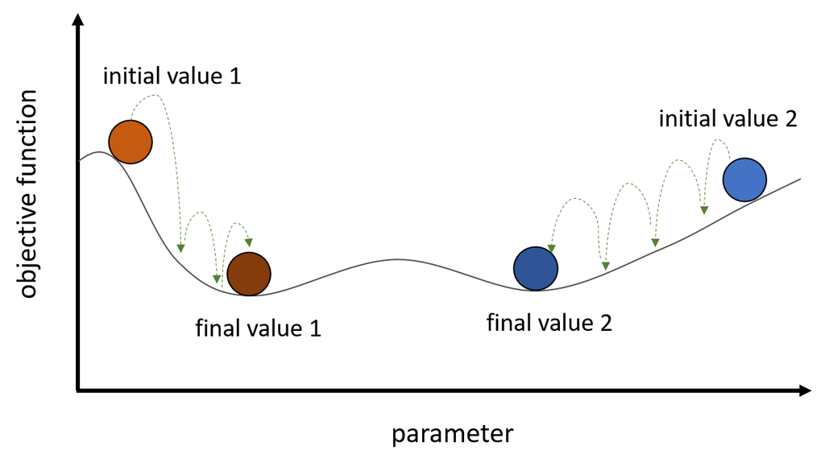

Figure 3.4: Given two different randomly selected parameter initial estimates the gradient descent method with give two different solutions. If we interpret the parameter we should be careful as it may not be the only plausible result. Finding a solution such as this in an optimisation problem is called a local optimum.

If we can get significantly different models depending on a random state we need to communicate that this is the case. Models that rely on random elements need to be robustly tested before the interpretations given from them are interpreted.

Most of the intrinsically interpretable models shown in the previous section are not significantly impacted by random perturbations, but this effect can increase as model and data complexity increase.

**Quality Questions**

What stochastic effects are at play in how this model was developed?

## 4.2 Opaque Data

A lot of discussion of interpretable predictive modelling is centered around the model type / algorithm chosen to learn the rules. While this is important, it does hide the significant impact that the data trained with has on opaqueness.

Very rarely is data passed directly from collection straight into a algorithm to produce a model.

At minimum processing occurs in order to format the data in a way the algorithm can use.

Sometimes the raw data itself can be challenging to understand, we will not explore this in much detail. The solution is to not use raw data that can’t be understood in a modelling system.

Often the processing will go beyond reformatting and basic cleaning. “Feature Engineering” - extracting new values from our raw data, can improve model performance substantially. However, it can cause our model to be harder to understand.

In a not opaque model we would be able to relate the features of the data to why a prediction was made.

The mapping of a feature to an outcome can be challenging when:

- We didn’t understand the feature to begin with
- We combined too many features to create new ones, meaning the resulting features given to the model are hard to interpret
- We transformed understandable features into not-easily understood ones using mathematical functions (often called kernels)

There are situations where the above is appropriate and useful, however, we should be aware that we are making a model more opaque by using them.

Is the data transformation making the model more opaque justified with respect to our performance and interpretability goals.

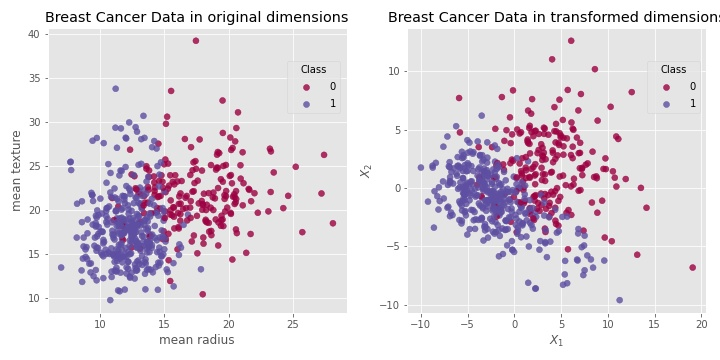

Figure 3.5: When we create a model using the first set of data we will be able to undertand the model directly with relation to the observed variables. When we transform data, such as in this example with principle component analysis, it can become more challenging to relate the directly observed data to the final model output. The transformed data may improve the models performance, so we will need to take into account what we value in the modelling.

## 4.3 Discussion

**Question**

What is the value in black-box modelling?

**Suggestions**

This course intentionally takes a negative view of blackbox models. This is for a few reasons:

- they can be damaging when deployed at scale
- their performance compared to interpretable models is often over-stated
- those ensuring the quality of predictive models should champion interpretable models, if not them, then who?

But that doesn’t mean they are worthless, but rather they should be used sparingly and with precautions.

Black-box models can often model phenomena, such as those arriving form unstructured (text, image) data that other models cannot.

When leveraged with large amounts of data, performance can be impressive, great for low-risk predictions.

If there is adequate data, they can be used as an upper performance bound for bench-marking other models.

# 5 Documenting Design Decisions

If we want our predictive modelling application to be ethical we need it to be transparent. Transparency has a range of lenses, how interpretable the results are being just one.

Principle 6 of the UKSA Ethical Principles states “The access, use and sharing of data is transparent, and is communicated clearly and accessibly to the public.” A predictive model trained on data is using that data, therefore we need to be able to clearly communicate how it was created. That can only be done if the information is recorded.

In a predictive modelling application there will be internal and external documentation, both are important for our model to have it’s quality assured and trusted.

Internal documentation needs to be enough explanation and detail such that the work can be reproduced by someone within the organisation, or with access to the same data and code. External documentation describes what the model does, why it does it, and how it was created at a high level to the public (or relevant stakeholder).

In principle 5 of the Ethical principles it highlights that the public is considered in light of the data used and the benefits of the research. The public need to be aware of the model to an appropriate degree, this requires documentation and communications.

We never arrive at a final predictive model by just following a recipe book. From concept inception there are a large number of **decisions** that are made, which all culminate in the final model.

The final model cannot be fully understood without the **context** in which it was created. The decisions made that influence and **why** they were made is crucial to understanding the model.

## 5.1 Documentation

You may remember from previous discussions our model is made up of a few components:

- Training Data
- A Learning Algorithm
- Design Choices

Data is relatively easy to store, explain and if necessary share, most learning algorithms can be understood reasonably well by analysts, however, if not recorded, the design choices that lead to a final model can be inexplicable.

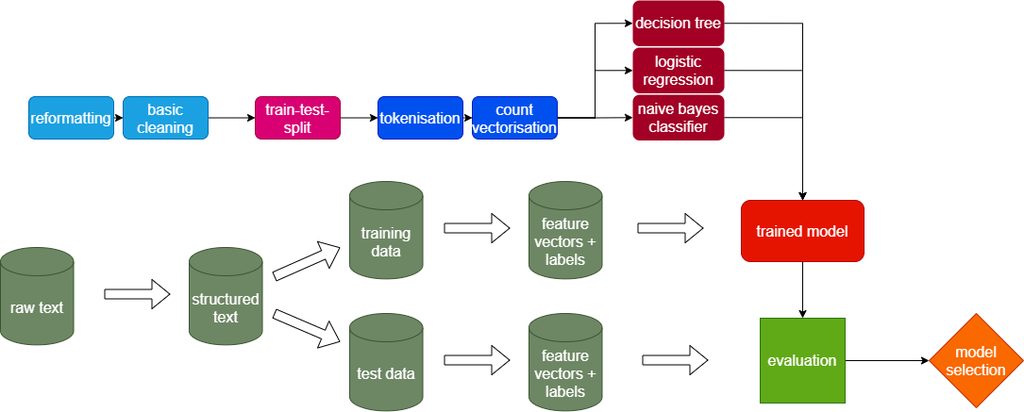

Figure 3.6: An example documentation diagram showing the steps involved in the model production. These XML diagrams can help visualise the process in a program without needing to scroll through the code. Using this we can query more easily why each step is there, and ask more detail about the lower level steps.

Modelling is conducted through code, therefore all relevant [documentation guidance for programming](https://best-practice-and-impact.github.io/qa-of-code-guidance/code_documentation.html) and [data management](https://best-practice-and-impact.github.io/qa-of-code-guidance/data.html) are relevant to our purposes in the first instance.

Important decisions which should at minimum be written down at the time of decision:

- What is the goal?
- Why is this data being used?
- Why this data cleaning approach?
- Why this model / learning algorithm?
- Proof of evaluation of different approaches
- Feedback from peer review / disagreements

**Quality Questions**

Is there a document with a log of decisions made by those involved?

Is the code commented adequately?

Has the process been peer reviewed?

## 5.2 Reproducibility

Any model in use should be able to be recreated and understood by an individual who did not create it in order for it to be quality assured. Without documentation, explanations for how to recreate a model at both a high level (such as “preprocess the data like XYZ”, 2. train the model”) and low level (comments in the code explaining why each step is necessary) this becomes impossible.

Again, we must first follow the standards for general coding first, such as this [code quality checklist](https://best-practice-and-impact.github.io/qa-of-code-guidance/checklists.html).

By using well documented code we can often easily record decisions as we experiment, however this is something which needs to be encouraged. It is easy to fall down a rabbit hole and forget to record important decisions made by analysts or stakeholders.

A simple test as to whether there has been adequate documentation is whether another individual can recreate the work, if they cannot, add more **clearer documentation** until they can. Having this back and forth with multiple people helps support reproducibility.

The inclusion of good comments can be invaluable within code to understand what the analyst was thinking when they wrote the code, and will help trace back decisions.

Where important design decisions are made, there should be sign off or review from multiple groups, this will ensure others are kept up to date in progress, and that the modelling is heading in an appropriate direction. It is much easier to pick up errors earlier rather than later.

Reproducible models are easier to quality assure, they increase our confidence in the methods chosen.

**Quality Questions**

Has a separate analyst reproduced the model?

### 5.2.1 Challenges in Documenting Design Decisions

Documentation in of itself is a challenging part of a design process. It is not immediately rewarding, but nevertheless more valuable than most steps in the design process.

Below are some example challenges which can prevent adequate documentation from being created:

- Some tools like Jupyter Notebooks, are powerful for exploration and document writing, but can easily be used poorly with models being unsaved, and unclear dependencies being created.
- There are such a large quantity of decisions made that recording them all takes more time that the experimentation, a balance needs to be struck.
- When only one analyst works on a project much of the important modelling design decisions may have been made alone and just be “in their head”. Encouraging group work, peer review and knowledge exchange can prevent this. This can be a particular challenge if there is only one member of the team with the capability/capacity to work on this project.
- In a rapidly moving experimentation it can be viewed as more important to produce results rather than get stuck writing descriptions. This culture of analysis needs to be avoided / mitigated.

By writing design decisions down a model becomes more than just the code, maths and data that was used to create it.

The role of the analytical ensurer can help drive this good practice in documentation. Having the analyst constructively challenged about design decisions helps to record important / unclear decisions.

Ultimately, more documentation benefits everyone, but it needs to be encouraged and set as a standard.

**Quality Questions**

Has the code used to create the model been version controlled and reviewed?

How is the data used to create each model versioned/stored?

Can different models be explored without retraining?

# 6 Feedback Loops

**What is the impact of this prediction?**

If our system has any purpose it will be making predictions that have an effect. Whether this is a life changing effect (hopefully not), or a minor administrative change for a business, if we are bothering to use a predictive model there will be a real world impact.

Feedback in this course will broadly used as a term for “unexpected consequences” or when a prediction impacts a system in an way that was not planned for.

This section ties in to the Ethical Principle 1: “The use of data has clear benefits for users and serves the public good.”

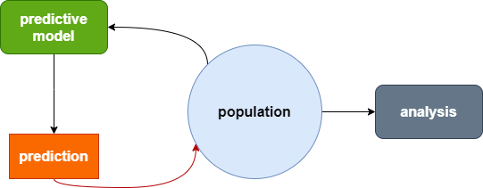

Figure 3.7: A prediction about an entity can easily impact the entity, affecting analysis of the population it belongs to later down the line. If our model is bad at predicting credit card default rates, people who are disadvantaged by this model will eventually be viewed as defaulters in other areas of analysis.

It is crucial we are aware of what this real world impact is, and how it fits into:

- The values of the organisation (ie your government department)
- The training process for this, existing or future models / analysis
- The stakes/risk involved

**Quality Questions**

What is the risk involved?

Does this prediction reinforce a societal bias?

Will the predictions made here change conclusions drawn elsewhere?

What will the long-term effects of this model be on data collection?

Naturally, we need to have our tolerance for feedback loops in our predictive modelling proportionate to the stakes involved.

It is important we understand what the risk of creating a feedback loop will be for our system.

For example, if we predict based on user profiles on our website what their preferred default cursor looks like, this has very low stakes. If we get the prediction wrong there is minimal impact on our reputation, or impact on the individual’s well being. If this system has some element of feedback which produces a systemic issue in our modelling system, we just get some bad cursor predictions.

Just because there is low risk / impact, doesn’t mean this is acceptable, however our tolerance will be higher for feedback effects.

If instead we are predicting based on an application whether a request for Universal Credit was fraudulent. If the model predicts that the application may have been fraudulent this is taken into account and a investigation will commence. This can have catastrophic effects if we do not carefully work through the potential feedback effects.

For example, if the person was investigated as a result of the model and found to have submitted a fraudulent claim, this will be used as a positive result of the model working. Future updates to the model may include this data point for training. This will make the model more likely to pick up similar future cases. But some important information is missed here, what about the predictions that the model got wrong? It will not have more positive information for this case, and will just get better at what it already knows.

In this example, thankfully there was some *human-in-the-loop*, an investigation did occur, the model was not the only decision maker in the process. However, this is not always the case, which can cause our model mistakes and feedback loops to compound and grow.

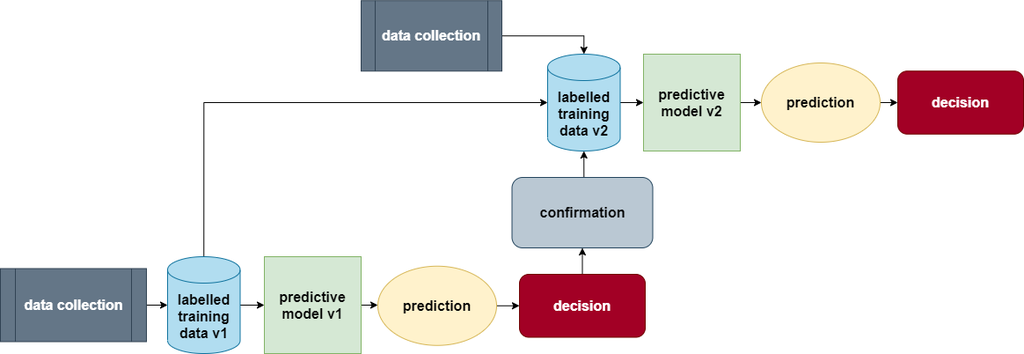

Figure 3.8: If care is not taken the prediction of a model can become training data for another. The biases and error of the original model will be propagated to the second. Often the effect will not the due to the data we have included to train, but what we have unconsiously excluded.

We will discuss in further detail ensuring that models do not have disproportionate impacts on different characteristics of individuals impacted by predictions in later sections. Here however, we will highlight why this can become more than an issue for individual predictions.

1. **Scale**

Predictive models can be deployed to make or influence decisions at a scale otherwise impossible. This means that it is easy to lose sight of the impact on individuals, this is the same problem with only looking at aggregations and summary statistics. **It can feel easier to abdicate responsibility to an algorithm, than to take responsibility as the owner**.

Instead of having a human make a decision or an agreed upon set of rules, the model can produce predictions **that may be better than humans overall, but not for individuals**. This scalability means the potential impact of a system is substantial, difficult to measure, and therefore more likely to influence wider society, other analyses, systems or conclusions drawn.

A model that affects some users of a website has a very different scale than a model applied to all of the population. The risk of feedback increases as the model applies to a higher proportion of a population.

**Quality Questions**

What other models look at this population?

What other analysis is drawn from this data?

What will the long term effects of consistent error be?

2. **Impact**

There are a range of areas predictive models can be applied to. Mathematically, they are all quite similar, however, in reality the impact that deploying the model into the real world can be drastically different. If a prediction is profiling or making an automated decision it must comply with the regulations set out in GDPR.

It can be difficult to quantify the impact a model will have on individuals lives, **but this doesn’t mean they can be ignored**.

It’s very different to incorrectly predict the correct amount of cloud cover in two weeks than misdiagnosing a disease.

These topics are discussed in further detail in Cathy O’Neil’s book “Weapons of Math Destruction”, which is recommended reading. A talk of the same name delivered by the author is [available on YouTube](https://www.youtube.com/watch?v=TQHs8SA1qpk)

**Quality Questions**

Does this prediction impact individuals?

What will the impact of incorrect predictions be?

What is being done to mitigate the adverse effects of errors?

What is in place to prevent predictions impacting other analysis?

## 6.1 Discussion

**Question**

Consider an algorithm that predicts how well you will do at your job based on your previous work / appraisals and experience.

It was trained on historic data from your organisation.

The result of this algorithm is seen by your manager who decides if you get a promotion.

What feedback loop effects would you expect to see?

**Answer**

As the data is historical, it will contain the historical biases of the (near) past, which may disadvantage some equally performing people based on the performance of people with similar characteristics.

Whether you get this promotion, or how long that takes, will be fed directly or indirectly into the decision for your next promotion.

How you work will be impacted by the result of the algorithm, a negative prediction may cause you to change habits which will be recorded for the next prediction.

While a different context, the [algorithm explored in this news article used in probabtion services would have similar negative feedback effects](https://www.nytimes.com/2020/02/06/technology/predictive-algorithms-crime.html).

# 7 Contestability + Conviction

Contestability and conviction are two separate, but related concepts.

Within the GDPR regulation checklist on solely automated decision making it states:

> “We have a simple way for people to ask us to reconsider an automated decision.”

This means that individuals **must** be able to ask to reconsider a prediction from a model.

All models created have errors, this is built in to the nature of modelling. Therefore any model **will** make incorrect predictions. It is important that we both:

- Minimise the size of that error
- Are able to correct the error when it occurs

In order for an individual to question the accuracy of a prediction, they must first know that an automated decision has been made.

**Quality Questions**

Does an individual know a decision has been made about them?

Can the individual trigger a non-automated decision?

If we have an interpretable model we can explain why a decision was made. If the model predicted incorrectly and we have an interpretable model we can work out how to improve the model. If our model is not easily interpretable then we cannot give more information to the individual about why their prediction was incorrect.

*Note we are not required to tell an individual why a decision was made under GDPR, but we should at minimum be able to explain it to ourselves*.

## 7.1 Conviction

As part of principle 3 of Ethical principles “The risks and **limits** of new technologies are considered…”, limits here being crucial.

**How certain about this prediction is our model?**

Some of the models we have mentioned provide probabilities of class membership (65% likely class A, 35% class B, for example). This can be really useful for two reasons:

- When contested, tested or evaluated we can use this information to inform the design process
- We can threshold the level of certainty

For the first reason, having a measurable level of conviction (probability or some other metric) allows us to not only look at the errors our model produces, but looking closer we can see **how** wrong, even based on a simple binary choice. If our model was not confident about a bad prediction that’s a different situation than if it was certain about a bad prediction.

If we output a prediction and its certainty from a model, we can then weigh the prediction (either in our heads or using some metric) when it comes to a decision.

For the second reason we can **choose a minimum level of certainty** that must be met in order for the model to make a prediction. We could for example say, only make a decision if the model is >80% confident about the prediction. If it’s not confident then we are best using some other manual process.

With high conviction there is often lower error, therefore we can gain the benefits of an improved prediction while preventing bad predictions from happening.

If we do not threshold our models with confidence levels, we may end up having very different decisions for data points that have 51% and 49% confidence about being in class A, which could have a substantial impact on an individual.

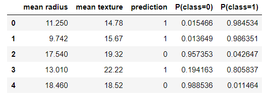

Figure 3.9: Each prediction on a new data point by the model can be explored for its certainty, even if we don’t know what the true value was.

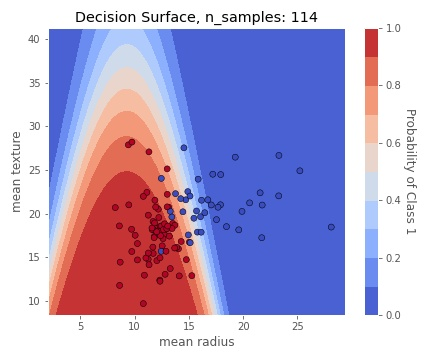

Figure 3.10: We can see the range of confidence the naive bayes model has across the possible prediction region. Many of the test data examples fall in this ‘uncertain’ region, so moving our threshold will change results. By default a threshold for a given class probability is 0.5.

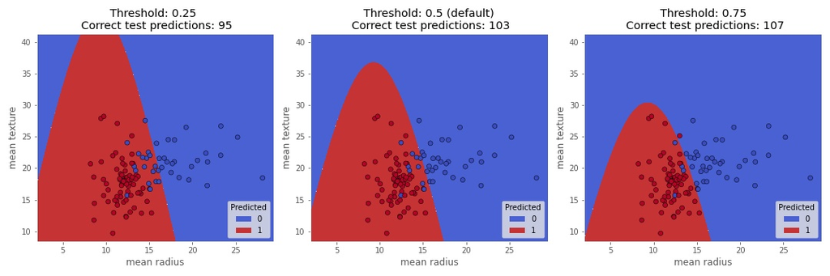

Figure 3.11: Different threshold probabilities for each class can impact how well our model predicts. Setting a different decision boundary can help us be more confident in certain class predictions. We can report the conviction we have for each prediction.

Instead of probabilities there are often other words used in the code such as **decision score**. Care should be taken when comparing between models as although they will quantify certainty, it will be in different ways.

Some models with some method for quantifying conviction:

- Any probability based model (e.g. Naive Bayes, Logistic Regression)
- Decision trees (probability is the class proportion of the decision leaf)
- Support Vector Machines (decision function - the distance from point to decision hyper-plane)
- K-Nearest Neighbours (probability is the neighbour vote class proportion)

We need to be aware of the limitations of each of these “probabilities” - they are not always well calibrated out of the box.

In some model types the model will actually produce a probability, which we then convert to a label prediction. In other instances a label will be predicted and a conviction score will be found using a separate method.

We do not need to inherently predict classes that have >50% prediction probability, in fact if we have imbalanced training data we can get better performance from using a different threshold.

Can the model produce a measure of uncertainty for each prediction?

Have the predictions been calibrated based on certainty?

What is an appropriate level of certainty for this system to make a prediction?

## 7.2 Discussion

**Question**

Consider the model that predicts your future work performance.

What percentage conviction would you let it influence your decision to give someone a promotion?

**Answer**

It’s impossible to come up with a specific number - we can ask for absolute certainty (100%), but this is likely unachievable.

Is 99% too high and also unachievable? It depends on the context. 99% certainty is different for “easy” or “hard” predictions.

These are the difficult questions we need to have someone understand and come to terms with.

If a human told you they were some percentage certain of an outcome, how would you trust that? We can’t take percentages from models at face value, it’s really hard for humans to predict with conviction (see: Superforcasters the book). What we need is assurance in the model’s ability to predict.

# 8 Measuring Characteristic Impact

All models will be incorrect. Based on the model type, data or both, the models will be incorrect in some situations more than others.

*How* incorrect the model is in different situations is an important property of the model, which needs to be understood before deploying it into use.

For example, the model may be worse at predicting whether the tourist will have ice cream at different times of the day, for people who always wear shorts, or even for protected characteristics such as race and gender.

We need to take the starting stance that **the model does have bias and is disadvantaging someone, to some extent**. Therefore our question is not **if** this is happening, but **why** and **how** can we mitigate it.

Fundamentally, we can only measure the impact that the model has on a group, type or situation if **we have representative information to compare it to**.

If we do not measure these effects, they will still happen.

We will first look at the “easier” case. We want to breakdown how the model performs by different groups, these groups are known and easily accessible. This may be because the characteristic information is included in the model, or because it can easily be linked with the entities predictions are happening to.

Next, we will explore what happens if we do not have adequate information to make judgments about the impact on different characteristics.

## 8.1 Known Characteristics

We will discuss in more detail in the next module how we can obtain more unbiased estimates of performance of our models. For now, we will just say that we should have some training data, used to create the model, and some test data that the model is evaluated with.

If we are exploring the model’s performance on a given characteristic/attribute then we need to **not use the data the model was trained on**. This will give us an overly optimistic evaluation and hide some generalised effects of the model.

When we have the characteristic information for each record in the test set we can quite simply explore how the model performs for each characteristic value. The simplest impact to check for is the accuracy of prediction. Is it equal across the different characteristic values? Does the prediction skew in a certain direction for different groups?

If the model is significantly better at predicting whether a tourist will buy ice cream on a given day, based on their nationality, then we need to 1) know this, 2) try to fix this, 3) report this effect so the risk can be taken into account when deciding if / when to use the model.

This is in effect trying to shine light onto the model, making it more transparent and easier to trust.

We will look below at a basic case study analysis of characteristic impact.

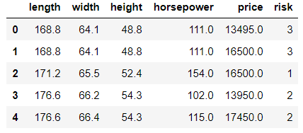

Figure 3.12: We are going to create a model that uses the features in the data set to predict the risk value. Higher values of risk correspond to what an insurer has denoted the risk of a specific car to be. A K-Nearest Neighbour Regression is performed with 5-fold cross validation, it’s errors/residuals explored.

We can explore how good our model is at predicting each of our different target values. This will tell us if our model is performing poorly for different outcomes, but not for characteristic qualities of the data directly. This will make us aware that although on average our model can perform well, specific outcomes are very likely to receive poor predictions.

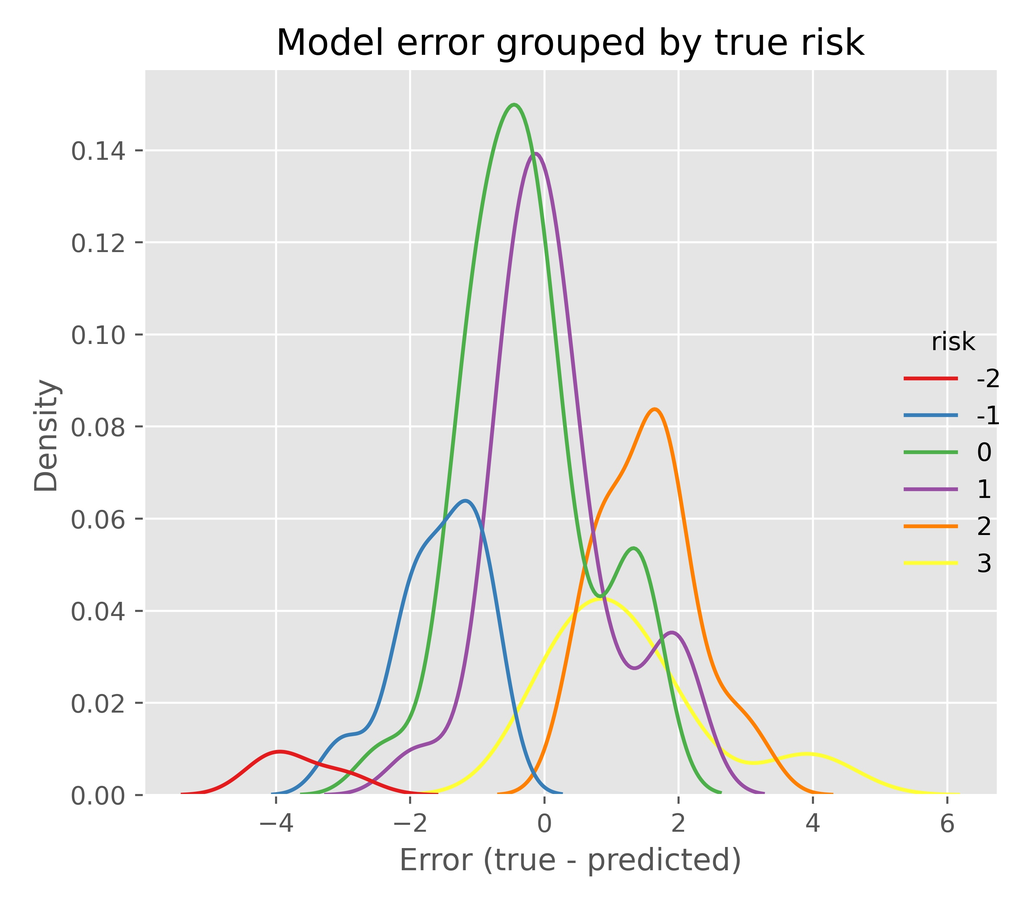

Figure 3.13: Ideally our model’s error is centered around zero. However, when we break down the different risk levels we actually get different shapes and average risks. From this plot we can see that the -2 risk (very low risk) predictions are being predicted very poorly, with a center near -4. This means the values are being predicted at around +2 risk for a true value of -2. This risk level is being continuously over predicted. Other risk values, particularly the more common values of 0 and 1, have peaks nearer 0, indicating our model is better at predicting these values. If we had more representative data we would be less skewed towards the center and have more examples to predict the more extreme values.

We will often want to explore how the model performs on characteristics that are **not part of the training data**. In this example each data point (car) has other characteristics that have not been fed into the model. For example, we can breakdown the error on the previously unseen car “body-style”. Even if we don’t use a certain feature in a model, it can still be invaluable to understanding how our model works, and who it might disadvantage.

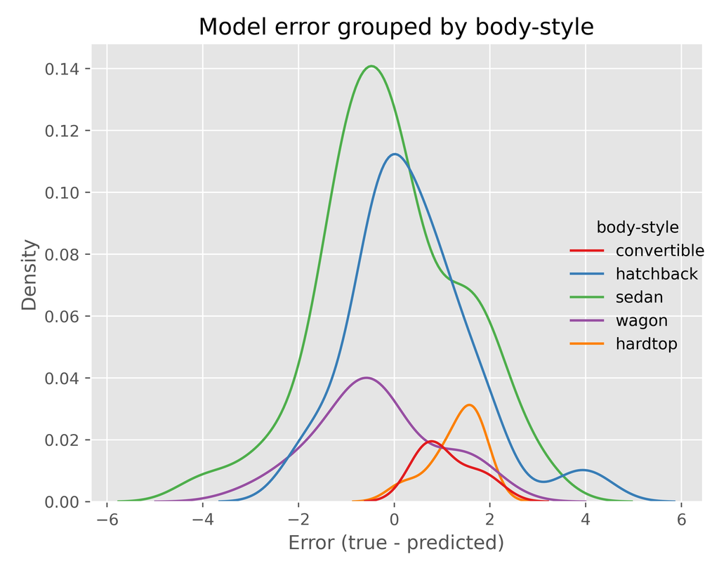

Figure 3.14: Breaking down the model’s prediction error by a feature not trained on allows us to investigate how the model will be disadvantaging. If our model is systematically incorrectly predicting a certain group of data points then we should know that before we use it.

We can use summary statistics on our error distributions for each characteristic to estimate the how incorrect the model is. Caveats around summary statistics and non-normal distributions apply.

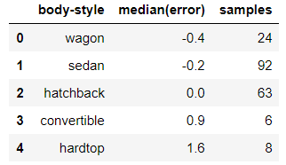

Figure 3.15: The most common cause of models performing badly on certain characteristics is a lack of training data with that characteristic value. The model learns from what it has seen, if it hasn’t seen enough of a characteristic it will struggle to predict similar future values.

This [Artificial Intelligence article](https://news.mit.edu/2018/study-finds-gender-skin-type-bias-artificial-intelligence-systems-0212) gives a description of a very harmful example where a lack of investigation of breakdowns by different groups can cause unequal discrimination by facial recognition systems.

**Quality Questions**

For who (or what entity/data point/situation) does the model perform better / worse?

What evidence of exploring impact across different groups is there?

Are the differences justifiable based on the modelling aims agreed?

## 8.2 Unknown Characteristics

The impact an algorithm will have across different groups is not always easy to predict. However, this makes it all the more important that the following steps are completed:

- Exploratory data analysis
- Discussion with domain experts
- Collaboration with diverse stakeholders
- Exploratory analysis on known characteristics

Without doing the above, there is little chance that all of the important effects the model will have on different groups will be caught.

While our data can give insight, what it is missing is often more important when it comes to ethical application.

As discussed in the last section, the most common reason for poor characteristic impact is a lack of representative training data. This could mean under-representing some class, or over-representing a different group.

What data is collected, and how it is collected impacts the model created significantly. This chapter in the book Data Feminism [“What Gets Counted Counts”](https://data-feminism.mitpress.mit.edu/pub/h1w0nbqp/release/2) describes the issues around representatives and priorities.

The main point to get across from this section is that whether or not you do the analysis for how the model performs on different groups, it will perform differently for different groups. The only way to know if a model is equitable is by shining the light on it and exploring it’s pitfalls. If the pitfalls are small and reasonable, great, if not the model needs to be re-designed.

**Quality Questions**

What groups of data are important in this population?

What groups have not been evaluated in the model’s performance?

More data in **what group** will reduce the bias in this model?

# 9 Summary

There are a wide range of components that make up an ethical predictive model.

Firstly, we need to ensure that our use of data is legal, we are transparent with users about the use of other data and how it is processed. GDPR gives us a good framework for assuring the ethics of our model at a basic level.

The gold standard we are looking for is transparent clear-box models that can be explained simply to users and stakeholders. When we add opaqueness to the model, we make it harder to understand, correct and get value from.

Models do not appear from thin air, a large number of design decisions are made along the way that will impact the model, and therefore those affected by the model’s predictions. It’s crucial that these design decisions can be audited, in order for this to happen the decisions themselves need to be written down.

The wider context of the model system needs to be taken into account before we use a prediction. The prediction may alter other analysis, future models or reinforce other biases in populations we work with. A comprehensive understanding of the impact a model may have in a wide context needs to be understood.

Whether or not a model is transparent means little to the person the prediction is applied to if they are unable to at minimum contest the prediction. There must be a mechanism for those affected by predictions to contest the prediction and pending review have it changed. Having degrees of confidence in our model’s prediction can help us tune the predictions to meet our standards of certainty for our application.

It’s easy to evaluate our models overall and compare models in aggregate - however, our models do no serve all those who use them equally. Models will perform worse for some groups, types or situations. We need to understand this difference in performance before we use the model. This difference will always be there in varying degrees, what is important is that we can *legally* collect data to determine if the bias is acceptable. If the difference in performance across different characteristics is not acceptable, we need to redesign the algorithm until it is.

**Next Module: Avoiding (Statistical) Bias**

In the next module we will explore concepts and techniques that are important in the modelling design process to reduce the bias of our models. This will give us both higher generalised predictive performance, and confidence in the model.